# Лабораторная работа №1

Операционные системы

Федорова А.И

Российский университет дружбы народов, Москва, Россия

## Актуальность

- В наше время необходимо использовать несколько ОС для различных видов деятельности. Переключаться между ними помогают виртуальные машины.

## Цели и задачи

Целью данной работы является приобретение практических навыков установки операционной системы на виртуальную машину, настройки минимально необходимых для дальнейшей работы сервисов.

## Материалы и методы

- Лабораторная работа подразумевает установку на виртуальную машину VirtualBox (https://www.virtualbox.org/) операционной системы Linux (дистрибутив Fedora). Выполнение работы возможно как в дисплейном классе факультета физико-математических и естественных наук РУДН, так и дома. Описание выполнения работы приведено для дисплейного класса со следующими характеристиками техники: Intel Core i3-550 3.2 GHz, 4 GB оперативной памяти, 80 GB свободного места на жёстком диске; ОС Linux Gentoo (http://www.gentoo.ru/); VirtualBox версии 7.0 или новее.

## Настройка пакетов BM

Вхожу в ОС под заданной вами при установке учётной записью. Переключаюсь на роль супер-пользователя. И о бновить все пакеты с помощью dnf -y update (рис. fig:001).

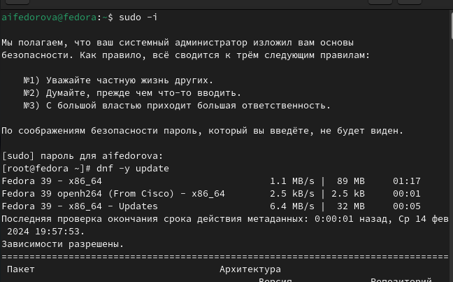

## Настройка пакетов BM

Устанавливаю программы для удобства работы в консоли. (рис. fig:002).

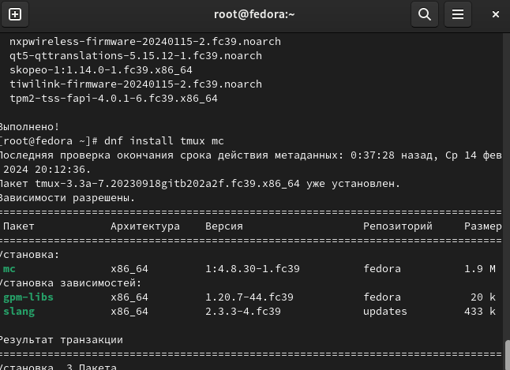

## Настройка пакетов BM

При необходимости можно использовать автоматическое обновление. Установка необходимого программного обеспечения для этого(рис. fig:00)3

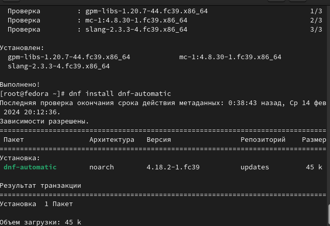

Задаю необходимую конфигурацию в файле /etc/dnf/automatic.conf. Запускаю таймер(рис. fig:004)

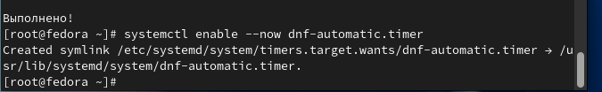

Теперь я отключу SELINUX.В файле /etc/selinux/config заменю значение SELINUX=enforcing на значение SELINUX=permissive (рис. fig:005)

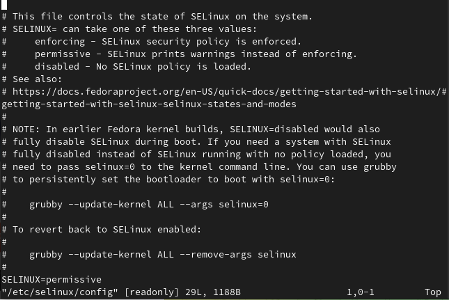

Перезагружу виртуальную машину с помощью команды reboot.

## Настройка драйверов для ВМ

Теперь я попробую установить нужные драйвера, запустив терминальный мультиплексор tmux. Переключюсь на роль супер-пользователя. Затем я установлю средства разработки “Development Tools”(рис. fig:006)

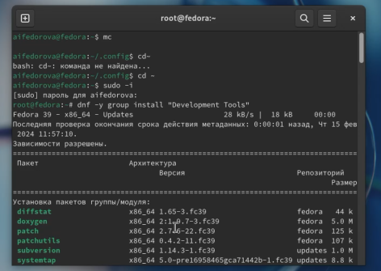

## Настройка драйверов для ВМ

Далее установлю пакет DKMS(рис. fig:007)

[figure not shown]

## Настройка драйверов для ВМ

Теперь я должна подмонтировать диск с помощью команды mount. Зайдя в меню виртуальной машины, я вижу, что оптический диск уже установлен (рис. fig:008)

[figure not shown]

## Установка имени пользователя и названия хоста.

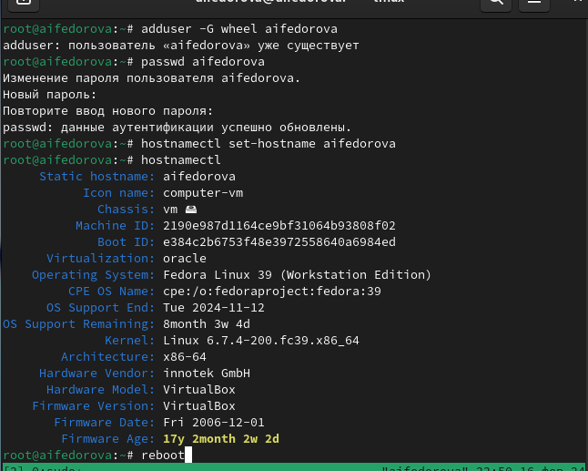

## Установка имени пользователя и названия хоста.

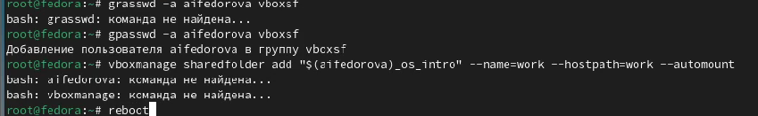

## Создание ПО для документации

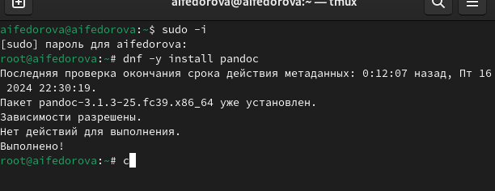

## Создание ПО для документации

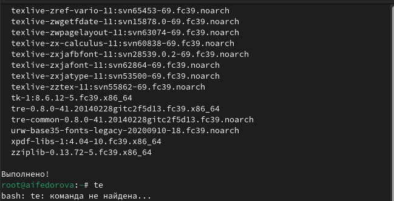

## Создание ПО для документации

Установим дистрибутив TeXlive (рис. fig:013)

[figure not shown]

## Анализ команды dsmg

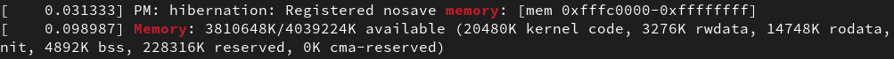

## Анализ команды dsmg

Также я узнала о размере доступной памяти в данный момент и о типе обнаруженного гипервизора. (рис. fig:016)

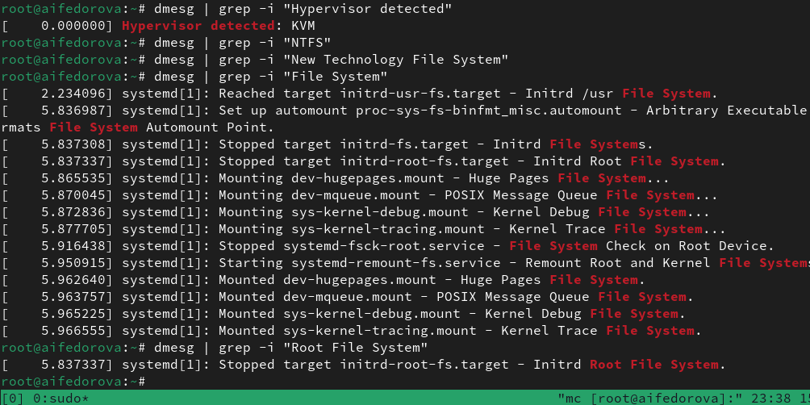

## Результаты

- Я настроила виртуальную машину для работы с ней
- Я смогла установить необходимые пакеты и обновления для удобного использования
- Получила практический опыт установки ОС на виртуальную машину Virtualbox.

## Итог

Если вы практикуете свои умения, то вы никогда их не забудете.